# Coding RUV via $THETA in NONMEM

- Show All Code
- Hide All Code
- View Source

Have you ever been confused why some people use the $THETA block to code their RUV in NONMEM? You are not alone!

RUV

Error

NONMEM

Author

[Marian Klose](https://github.com/marianklose)

Published

October 6, 2024

```r
# load packages
library(ggplot2)
library(tibble)
library(dplyr)
library(kableExtra)
```

**Summary**

- **Classical RUV Specification**: The classical way of specifying RUV in NONMEM involves directly specifying a variance in the `$SIGMA` block.
- **Alternative RUV Specification**: Coding residual unexplained variability (RUV) via the `$THETA` block in NONMEM allows direct estimation of standard deviation or coefficient of variation, rather than variance.
- **Fixed SIGMA Block**: In the “alternative” RUV coding method, `$SIGMA` is fixed to 1, making `EPS()` terms standard normal, which are then scaled by `$THETA` parameters representing standard deviations or coefficients of variation.
- **Additive vs. Proportional Models**: In additive error models, `$THETA` represents a standard deviation. In proportional error models, `$THETA` represents a coefficient of variation (CV) relative to the predicted value (`IPRED`).
- **Combining Error Components**: For combined proportional and additive error models, the joint standard deviation (`SD`) is computed as the square root of the sum of squared standard deviations, due to variance additivity rules.

When I started my PhD in pharmacometrics, I wanted to try something fancy[^1]: specifying a combined proportional and additive error model in NONMEM for one of my projects. A colleague kindly sent me a reference model, and to my confusion, the code included a (at least to me) novel way of defining residual unexplained variability (RUV):

```
alternative way (combined)
```

```r
$THETA
0.15        ; RUV_PROP
0.23        ; RUV_ADD

$ERROR
IPRED = F
SD_PROP = THETA(1)*IPRED
SD_ADD = THETA(2)
SD = SQRT(SD_PROP**2 + SD_ADD**2)
Y = IPRED + SD * EPS(1)

$SIGMA
1 FIX
```

It wasn’t immediately clear why it was set up this way, and I was left with some questions:

- Why is the RUV in the `$SIGMA` block fixed to 1? And why only one entry, given we have both proportional and additive components?
- What’s with the scaling parameter `SD`?
- Why are we squaring the proportional and additive error components and then taking the square root?
- How do we interpret the units for `THETA(1)` and `THETA(2)`?

It seemed a bit odd to me. I was more familiar with defining RUV directly in the `$SIGMA` block, something like:

```
classical way v1
```

```r
$ERROR
IPRED = F
Y = IPRED + IPRED * EPS(1) + EPS(2)

$SIGMA
0.0225
0.0529
```

or maybe in a slightly more elegant form:

```
classical way v2
```

```r
Y = IPRED * (1 + EPS(1)) + EPS(2)
```

So, why use this “alternative”[^2] way of defining the error? Before we try to explain this way of writing a combined error model to ourselves, let’s break down the additive and proportional error model separately to understand what’s going on. Please note: most of this theory can also be found elsewhere, such as in (Proost 2017).

## Additive error models

The “classical” way (if I can call it that) of specifying an additive error model in NONMEM is as follows:

```
classical way (additive)
```

```r
$ERROR
IPRED = F
Y = IPRED + EPS(1)

$SIGMA
0.0529
```

In this approach, RUV is defined directly in the `$SIGMA` block, where `EPS(1)` is assumed to be normally distributed with a mean of 0 and variance of 0.0529:

$$EPS(1) \sim \mathcal{N}(0,0.0529)$$

Now the *alternative* way (my colleague called it the *Uppsala way*[^3]) of coding the additive error model looks like this:

```
alternative way (additive)
```

```r
$THETA
0.23        ; RUV_ADD

$ERROR
IPRED = F
SD_ADD = THETA(1)
Y = IPRED + SD_ADD * EPS(1)

$SIGMA
1 FIX
```

Here, `$SIGMA` is fixed so `EPS(1)` has a variance of 1, effectively making it a standard normal distribution:

$$EPS(1) \sim \mathcal{N}(0,1)$$

But we then multiply this random variable `EPS(1)` by a scaling factor `SD_ADD` (which is being estimated as a `THETA` parameter) before the product is being added to the individual predicted `IPRED` value. Let’s visualize what happens when we fix `$SIGMA` to 1 and multiply it by `SD = 0.23`.

In a first step we will plot a standard normal distribution (`$SIGMA 1 FIX`):

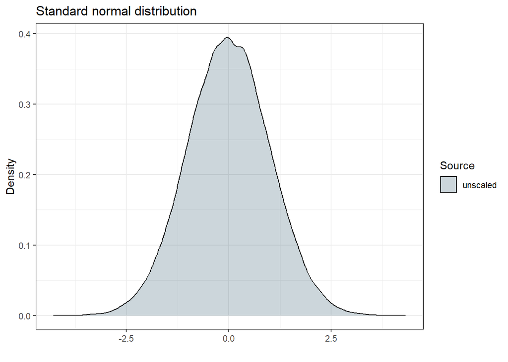

```r
# sample from standard normal distribution
x <- rnorm(100000, mean = 0, sd = 1)
std_norm <- tibble(x = x, source = "unscaled")

# plot
std_norm |>
  ggplot(aes(x = x, fill = source)) +
  geom_density(alpha=0.2)+
  labs(title = "Standard normal distribution", x = "", y = "Density")+
  scale_fill_manual(
    "Source",
    values = c(
      "unscaled" = "#003049"
    )
  ) +
  theme_bw()
```

The resulting standard deviation should be 1, and since $1^2 = 1$, the resulting variance should also be 1. Let’s check our empirical estimates (it is a simulation, after all) to confirm this:

```r
# summarize data and calculate sd and variance
std_norm |>
  group_by(source) |>
  summarize(
    sd = sd(x) |> signif(digits = 2),
    var = var(x) |> signif(digits = 2)
  ) |>
  rename(
    "Source" = source,
    "Standard Deviation" = sd,
    "Variance" = var
  ) |>
  kbl() |> kable_styling()
```

| Source | Standard Deviation | Variance |
| --- | --- | --- |
| unscaled | 1 | 1 |

Good. But what happens now to this standard normal distribution if we multiply the random variable with some scaling parameter $SD = 0.23$? Let’s find out:

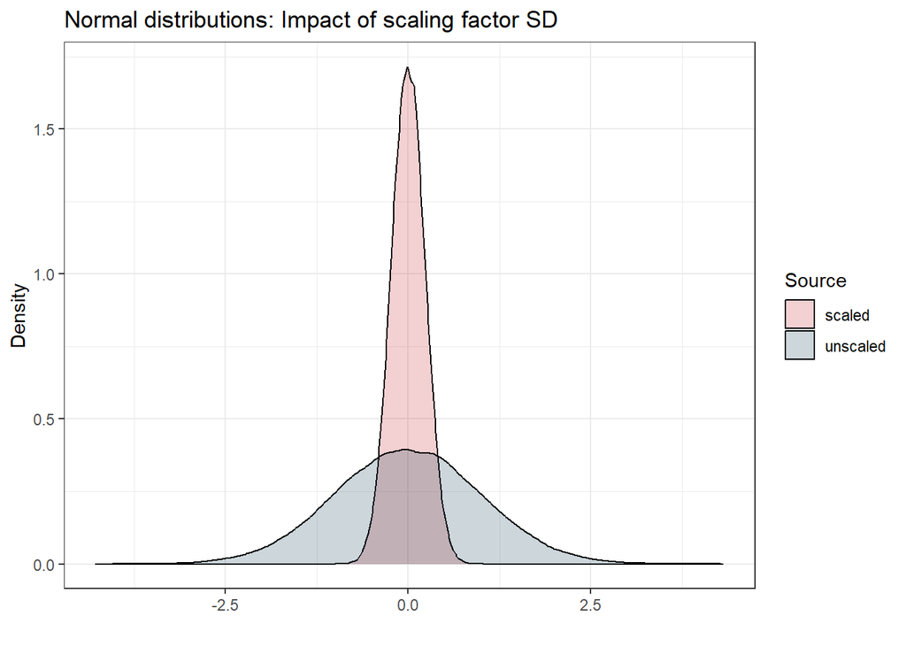

```r
# set a seed
set.seed(123)

# multiply with W
SD <- 0.23
x_scaled <- x * SD
std_norm_scaled <- tibble(x = x_scaled, source = "scaled")

# combine both
std_norm_combined <- bind_rows(std_norm, std_norm_scaled)

# plot
std_norm_combined |>
  ggplot(aes(x = x, fill = source)) +
  geom_density(alpha = 0.2)+
  labs(title = "Normal distributions: Impact of scaling factor SD", x = "", y = "Density")+
  scale_fill_manual(
    "Source",
    values = c(
      "unscaled" = "#003049",  # Blue color for original
      "scaled" = "#c1121f"     # Orange color for scaled
    )
  ) +
  theme_bw()
```

Let’s compare the standard deviation and variance of both distributions:

```r
# summarize data and calculate sd and variance
std_norm_combined |>
  group_by(source) |>
  summarize(
    sd = sd(x) |> signif(digits = 2),
    var = var(x) |> signif(digits = 2)
  ) |>
  rename(
    "Source" = source,
    "Standard Deviation" = sd,
    "Variance" = var
  ) |>
  kbl() |>
  kable_styling()
```

| Source | Standard Deviation | Variance |
| --- | --- | --- |
| scaled | 0.23 | 0.053 |
| unscaled | 1.00 | 1.000 |

For the scaled distribution, we can see that the resulting standard deviation $\sigma$ is approximately equal to our scaling factor `SD_ADD` (which is 0.23) and the variance is $0.23^2 \approx 0.053$. This means that in our model code

```
alternative way (additive)
```

```r
SD_ADD * EPS(1)
```

the `SD_ADD` parameter (specified via `$THETA`) is representing a standard deviation. Cool thing! This is why both of these models are equivalent:

```
classical way (additive)
```

```r
$SIGMA
0.0529   ; variance
```

and

```
alternative way (additive)
```

```r
$THETA
0.23   ; standard deviation

$SIGMA
1 FIX
```

To sum it up: We need to be careful with the units. If we use the *classical* way, the `$SIGMA` estimate is a variance, but if we use the *alternative* way, the `$THETA` estimate is a standard deviation. Typically, we would report the standard deviation (rather than the variance) if we use an additive model, and I think one of the advantages of the *alternative* way is that we directly read out the standard deviation from the parameter estimates (without the need to transform anything). Some also say that the estimation becomes more stable if we model the stochastic parts via `$THETA`, but I cannot judge if this is true or just a myth.

**Specifying additive RUV via $THETA gives us a standard deviation**

Whenever we have an additive error model and we specify the RUV in the `$THETA` block (the *alternative* way), the resulting estimate is a standard deviation.

## Proportional error models

Now, let’s look at proportional error models. The *classical* way of specifying the proportional error model looks like this:

```
classical way (proportional)
```

```r
$ERROR
IPRED = F
Y = IPRED + IPRED * EPS(1)

$SIGMA
0.0225
```

And the *alternative* way is:

```
alternative way (proportional)
```

```r
$THETA
0.15        ; RUV_PROP

$ERROR
IPRED = F
SD_PROP = IPRED * THETA(1)
Y = IPRED + SD_PROP * EPS(1)

$SIGMA
1 FIX
```

The structure is similar to the additive model we discussed earlier, except that the standard deviation of the random noise around our prediction depends on the prediction itself. This is why we first calculate the standard deviation `SD_PROP` at the given prediction as:

```
alternative way (proportional)
```

```r
SD_PROP = IPRED * THETA(1)
```

This already gives us an understanding of the units of `THETA(1)`: it represents the coefficient of variation (CV) of the prediction `IPRED`. Why? A coefficient of variation represents the ratio of the standard deviation to the mean. This is why we end up with a standard deviation (`SD_PROP`) if we multiply the prediction (`IPRED`) with the CV (`THETA(1)`).

### An example

Suppose we have a prediction (`IPRED`) of 10 mg/L and we want to show the resulting distribution. For the *classical* approach, we would specify a variance (`EPS(1)`) of 0.0225, and for the *alternative* way, we would specify a CV (`THETA(1)`) of 0.15. What do you think? Will this be equivalent or not? Let’s find out!

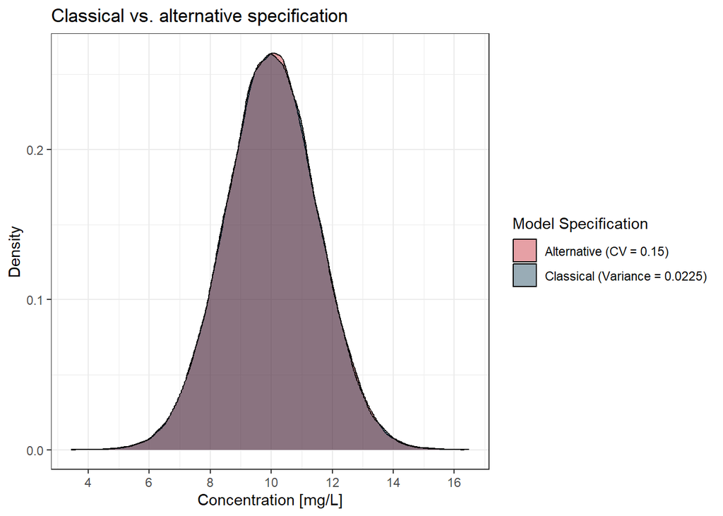

```r
# Set seed for reproducibility
set.seed(123)

# Parameters
IPRED <- 10
CV_percent <- 0.15
SD_prop <- CV_percent * IPRED
sd_classical <- IPRED * sqrt(0.0225)

# Number of samples
n <- 100000

# Classical way: Specify variance directly
eps_classical <- rnorm(n, mean = 10, sd = sd_classical)

# Alternative way: Specify CV%
eps_alternative <- rnorm(n, mean = 10, sd = 1 * SD_prop)

# Create a tibble combining both distributions
prop_models <- tibble(
  value = c(eps_classical, eps_alternative),
  source = rep(c("Classical (Variance = 0.0225)", "Alternative (CV = 0.15)"), each = n)
)

# Plot the density of both distributions
prop_models |>
  ggplot(aes(x = value, fill = source)) +
  geom_density(alpha = 0.4) +
  labs(
    title = "Classical vs. alternative specification",
    x = "Concentration [mg/L]",
    y = "Density"
  ) +
  scale_fill_manual(
    "Model Specification",
    values = c(
      "Classical (Variance = 0.0225)" = "#003049",  # Blue
      "Alternative (CV = 0.15)" = "#c1121f"      # Red
    )
  ) +
  scale_x_continuous(breaks=c(4,6,8,10,12,14,16))+
  theme_bw()
```

Both models end up with the same distribution. In the *classical* way, we are given a variance of 0.0225. To get the standard deviation, we take the square root of the variance:

$$\sigma_{EPS} = \sqrt{0.0225} = 0.15$$

This estimate of 0.15 already serves as a CV, as we are then multiply this by the prediction (`IPRED`) of 10 mg/L to get the standard deviation of the prediction distribution:

$$\sigma_{PRED} = 0.15 \times 10 = 1.5 \, \text{mg/L}$$

In the *alternative* way, we are directly given the coefficient of variation (CV) as 0.15. The CV represents the relative variability, so to get the standard deviation, we multiply the CV by the prediction (`IPRED`):

$$\sigma_{PRED} = 0.15 \times 10 = 1.5 \, \text{mg/L}$$

In both cases, the resulting variability is the same, meaning both approaches lead to the same standard deviation of 1.5 mg/L.

**Specifying proportional RUV in $THETA gives us a coefficient of variation**

Whenever we have a proportional error model and we specify the RUV in the `$THETA` block, the resulting estimate is a coefficient of variation.

## Combined proportional and additive error models

Finally, let’s combine our knowledge to understand the *alternative* way of specifying a combined proportional and additive error model:

```
alternative way (combined)
```

```r
$THETA
0.15        ; RUV_PROP
0.23        ; RUV_ADD

$ERROR
IPRED = F
SD_PROP = THETA(1)*IPRED
SD_ADD = THETA(2)
SD = SQRT(SD_PROP**2 + SD_ADD**2)
Y = IPRED + SD * EPS(1)

$SIGMA
1 FIX
```

Two parts should already be familiar:

```
alternative way (combined)
```

```r
SD_PROP = THETA(1)*IPRED
SD_ADD = THETA(2)
```

In the first part, we calculate `SD_PROP`, representing the resulting standard deviation of the proportional part (as `THETA(1)` is a CV). The second part, `SD_ADD`, gives us the standard deviation of the additive part. Now we want to find the joint standard deviation `SD` at the given concentration. But how do we combine these components?

```
alternative way (combined)
```

```r
SD = SQRT(SD_PROP**2 + SD_ADD**2)
```

We can see that we first square both terms, then add them together, then take the square root. Sounds complicated - why not just add them directly together? This is because variances are additive when combining independent random variables, while standard deviations are not (Soch 2020). Written a bit more formally for two independent random variables (we assume the covariance to be 0):

$$\mathrm{Var}(X + Y) = \mathrm{Var}(X) + \mathrm{Var}(Y)$$
In our case, `SD_PROP` and `SD_ADD` are standard deviations, so we must first square them to get the variances and then add them. However, we want to go back to a standard deviation before we multiply `SD` with `EPS(1)` (being fixed to 1). Therefore, we take the square root in the end.

**Combined error models**

When specifying a combined error model, the estimates in the $THETA block represent a standard deviation for the additive part and a coefficient of variation for the proportional part.

## Conclusion

This is a somewhat lengthy explanation of why we code the *alternative* approach in NONMEM. Personally, I wasn’t very familiar with how distributions behave when multiplying by a random variable, and I didn’t realize that while variances are additive when combining two random processes, standard deviations are not. If you have a stronger background in statistics, this might have been obvious, but I hope this explanation was still helpful for some.

## References

Proost, Johannes H. 2017. “Combined Proportional and Additive Residual Error Models in Population Pharmacokinetic Modelling.” *European Journal of Pharmaceutical Sciences* 109 (November): S78–82. https://doi.org/10.1016/j.ejps.2017.05.021.

Soch, Joram. 2020. “Variance of the Sum of Two Random Variables.” *The Book of Statistical Proofs*. https://statproofbook.github.io/P/var-sum.html.

## Footnotes

[^1]: Yeah, I know, not really fancy. But that’s how it feels when you touch a combined error model for the first time.
[^2]: For many of you, this is likely quite standard. The naming reflects my perspective.
[^3]: I’m not sure if this was initially introduced by one of the Uppsala groups or if this is just some hearsay.